# EDA Report

### High Popularity Spotify Dataset

### 1. Data Preparation Tasks

##### 1.1 Load the given dataset into a Pandas DataFrame

##### 1.2 Basic Dataset Overview

- total number of rows
- total number of columns.

```
Total number of rows: 1686
Total number of columns: 29
```

##### 1.3 List all column names and identify their data types:

- Numerical
- Categorical
- Datetime

```
After conversion of 'track_album_release_date' from object to 'datetime'
Data Types:
energy                             float64
tempo                              float64
danceability                       float64
playlist_genre                         str
loudness                           float64
liveness                           float64
valence                            float64
track_artist                           str
time_signature                       int64
speechiness                        float64
track_popularity                     int64
track_href                             str
uri                                    str
track_album_name                       str
playlist_name                          str
analysis_url                           str
track_id                               str
track_name                             str
track_album_release_date    datetime64[us]
instrumentalness                   float64
track_album_id                         str
mode                                 int64
key                                  int64
duration_ms                          int64
acousticness                       float64
id                                     str
playlist_subgenre                      str
type                                   str
playlist_id                            str
dtype: object

--- Column Classification ---
Numerical Columns (14):
['energy', 'tempo', 'danceability', 'loudness', 'liveness', 'valence', 'time_signature', 'speechiness', 'track_popularity', 'instrumentalness', 'mode', 'key', 'duration_ms', 'acousticness']

Categorical Columns (14):
['playlist_genre', 'track_artist', 'track_href', 'uri', 'track_album_name', 'playlist_name', 'analysis_url', 'track_id', 'track_name', 'track_album_id', 'id', 'playlist_subgenre', 'type', 'playlist_id']

Datetime Columns (1):
['track_album_release_date']
```

##### 1.4 Identify the target variable, if one exists in the dataset.

- In this Spotify dataset, the most natural target variable for a regression model is `track_popularity` (predicting how popular a song will be). Alternatively, `playlist_genre` or `playlist_subgenre` could serve as target variables for a classification task (categorizing songs into genres based on their audio features).

##### 1.5 Explain what the dataset represents in 2-3 sentences.

- This dataset represents a collection of highly popular songs on Spotify, along with their metadata and quantitative audio characteristics. Each row describes a single track, containing identifiers (such as track name, artist, and album), release dates, playlist details, and scientific acoustic metrics (such as danceability, energy, loudness, valence, and tempo).

##### 1.6 Describe why the dataset is suitable for an Exploratory Data Analysis (EDA) project.

- This dataset is excellent for EDA because it blends rich metadata (categorical fields like artist, album, and genre) with multidimensional numerical features (audio metrics, track duration, and popularity). This structure allows us to explore fascinating relationships, such as how audio attributes differ across genres, how music characteristics have evolved over time, and what specific features correlate most strongly with overall song popularity.

##### 1.7 Summarize any notable characteristics of the dataset that may be useful for further analysis.

- Key characteristics include a mix of scale profiles: audio metrics like `danceability`, `energy`, and `acousticness` are mostly normalized between 0 and 1, whereas `tempo`, `loudness`, and `duration_ms` operate on much larger, unscaled ranges. Additionally, the `track_album_release_date` exhibits mixed date formats (ranging from raw years to full ISO dates) that require robust parsing before chronological trend analysis.

### 2. Data Cleaning Tasks

#### 2.1 Identify Missing Values

##### 2.1.1 Check every column in the dataset for missing or null values.

```
energy                      0
tempo                       0
danceability                0
playlist_genre              0
loudness                    0
liveness                    0
valence                     0
track_artist                0
time_signature              0
speechiness                 0
track_popularity            0
track_href                  0
uri                         0
track_album_name            1
playlist_name               0
analysis_url                0
track_id                    0
track_name                  0
track_album_release_date    0
instrumentalness            0
track_album_id              0
mode                        0
key                         0
duration_ms                 0
acousticness                0
id                          0
playlist_subgenre           0
type                        0
playlist_id                 0
dtype: int64
```

##### 2.1.2 Calculate and report the percentage of missing data in each affected column.

```
--------- Missing Values Summary ---------
```

|  | Missing Values | Percentage (%) |
| --- | --- | --- |
| energy | 0 | 0.000000 |
| tempo | 0 | 0.000000 |
| danceability | 0 | 0.000000 |
| playlist_genre | 0 | 0.000000 |
| loudness | 0 | 0.000000 |
| liveness | 0 | 0.000000 |
| valence | 0 | 0.000000 |
| track_artist | 0 | 0.000000 |
| time_signature | 0 | 0.000000 |
| speechiness | 0 | 0.000000 |
| track_popularity | 0 | 0.000000 |
| track_href | 0 | 0.000000 |
| uri | 0 | 0.000000 |
| track_album_name | 1 | 0.059312 |
| playlist_name | 0 | 0.000000 |
| analysis_url | 0 | 0.000000 |
| track_id | 0 | 0.000000 |
| track_name | 0 | 0.000000 |
| track_album_release_date | 0 | 0.000000 |
| instrumentalness | 0 | 0.000000 |
| track_album_id | 0 | 0.000000 |
| mode | 0 | 0.000000 |
| key | 0 | 0.000000 |
| duration_ms | 0 | 0.000000 |
| acousticness | 0 | 0.000000 |
| id | 0 | 0.000000 |
| playlist_subgenre | 0 | 0.000000 |
| type | 0 | 0.000000 |
| playlist_id | 0 | 0.000000 |

##### 2.1.3 Select an appropriate treatment method for each column and justify your choice:

- Drop rows if only a small number of records are affected.
- Replace missing numerical values with the mean or median, depending on the data distribution.
- Replace missing categorical values with the mode, or most frequent value.

```
Detected 1 columns with missing values. Applying treatment:
  - Filled categorical 'track_album_name' with Mode: 'Un Verano Sin Ti'

Remaining missing values in dataset: 0
```

- For Numerical Columns: If any missing values were found, we would check the skewness of the distribution. For highly skewed fields (like sales revenue or unit count), the median is preferred because it is robust against outliers. For normally distributed fields, the mean is used.
- For Categorical Columns: Missing values are imputed with the mode (the most frequent value) because it is the most statistically representative category and maintains the original label distribution without introducing arbitrary new categories.

##### 2.1.4 Explain why the chosen method is suitable for preserving data quality.

This hybrid strategy ensures that we do not lose rows of valuable transaction history (which would happen if we dropped entire records) while keeping our data's descriptive statistics consistent and free of imputation bias.

#### 2.2 Remove all duplicate entries.

##### 2.2.1 Identify any duplicate rows in the dataset.

```
--- Duplicate Record Analysis ---
Number of duplicate rows found: 0
```

##### 2.2.2 Remove all duplicate entries.

```
Dataset shape before removing duplicates: 1686 rows x 29 columns
```

##### 2.2.3 Report:

- Number of duplicate rows found.
- Number of duplicate rows removed.
- New dataset shape, in rows x columns, after duplicate removal.

```
--------------REPORT--------------
Number of duplicate rows found: 0
Number of duplicate rows removed: 0
New dataset shape: 1686 rows x 29 columns
Remaining duplicate rows: 0
```

#### 2.3 Detect and Handle Outliers

##### 2.3.1 Select at least two numerical columns for outlier analysis.

##### 2.3.2 Use the Interquartile Range (IQR) method to detect outliers.

```
IQR of duration_ms is 68385.50
IQR of tempo is 36.77
```

##### 2.3.3 For each selected numerical column :

- Report the lower and upper bounds.

```
----duration_ms----
upper bound : 347571.5
lower bound : 74029.5
----tempo----
upper bound : 191.99562499999996
lower bound : 44.89662500000003
```

- State the number of outliers detected.

```
----duration_ms----
number of outlier : 44
----tempo----
number of outlier : 14
```

- **Explain the chosen treatment:**
  - Remove the outliers.
  - Cap the extreme values.
  - Retain them if they represent legitimate observations.

**Chosen Treatment:** **Retain all outliers** as they represent legitimate observations.

- **Action taken:** We did **not** remove any outliers, and we did **not** cap or winsorize the extreme values.
- **Justify the decision based on the dataset context.**

In data cleaning, it is a common mistake to automatically delete or cap outliers. However, in the context of a music dataset like Spotify, outliers are not errors—they are real-world artistic expressions. Here is why retaining these values is the only scientifically sound approach:

1. **Artistic Intent and Song Formatting:**
   - **Track Duration (`duration_ms`):** Song lengths naturally span a wide spectrum. A track under 90 seconds (like a short punk song, rap skit, or introductory track) or a track over 6 minutes (like a classic progressive rock song, DJ club mix, or classical composition) represents authentic human creation. Capping them would distort the true distribution of song structures.
   - **Tempo (`tempo`):** A song’s speed (BPM) reflects its genre and emotional delivery. Deep, slow ballads might run at 50–60 BPM (low outliers), while fast-paced Drum & Bass, Happy Hardcore, or speed-metal tracks can exceed 200 BPM (high outliers). Both are mathematically outliers but artistically 100% correct.
2. **No Technical or Measurement Errors:**
   - Outliers should only be removed if they are caused by measurement glitches (e.g., a song with a duration of `0` milliseconds or a negative tempo). Since all extreme values in our dataset represent physically possible and musically valid track configurations, removing them would mean discarding high-quality, genuine observations.
3. **Protection of Genre-Specific Data:**
   - Deleting outliers would disproportionately wipe out specific musical genres. For example, removing high-tempo outliers would delete modern EDM and Electronic music, while removing long-duration outliers would delete Classical, Jazz, and Progressive Rock. This would introduce a severe selection bias into our cleaned dataset.
4. **Crucial for Downstream Machine Learning Models:**
   - If we train a model later to predict `track_popularity` or classify songs into a `playlist_genre`, the model *must* understand that very short or very fast songs exist and can still become highly popular. Removing these records would oversimplify the dataset, leading to poor real-world predictive performance.

#### 2.4 Summary of Data Cleaning

The data preprocessing phase was executed systematically to ensure data integrity and musical consistency before entering the exploratory analysis stage:

1. **Missing Values:** A comprehensive programmatic check was performed across all columns. Any missing values in the descriptive text columns (such as missing track names or artists) or audio characteristics were analyzed. A defensive imputation logic remains active in our workflow: if any missing values occur, highly skewed numerical columns are filled using the median, while categorical columns are resolved using the mode (most frequent category) to prevent structural distortion.
2. **Duplicate Records:** An integrity analysis was conducted to find exact row duplicates (identical tracks appearing multiple times under the exact same parameters). By keeping only the first occurrence of each track and removing subsequent duplicates, we ensure that popular tracks do not artificially skew our statistical summaries or overrepresent certain artists/genres.
3. **Outlier Treatment:** Outliers were analyzed using a custom Object-Oriented Programming (OOP) class, `OutlierAnalyzer`, applying the Interquartile Range (IQR) method to track durations (`duration_ms`) and beats per minute (`tempo`). Outliers were identified at both the high and low ends. Based on the dataset’s musical context, these records were **deliberately retained** because they represent valid artistic choices (e.g., very long songs or high-BPM tracks like EDM and metal). Removing or capping them would introduce severe selection bias and misrepresent the actual variety of popular tracks on Spotify.

With these data verification steps complete, the dataset is verified as clean, structurally complete, and fully prepared for deep exploratory analysis and visualization.

### 3. Analysis and Insights

#### 3.1 Single Column Analysis

##### 3.1.1 numerical column analysis

- Pick one numerical column from the cleaned dataset.
- Create a histogram or box plot to show how the values are distributed.
- Write one simple observation about what the graph shows, such as spread, concentration, skewness, or outliers.

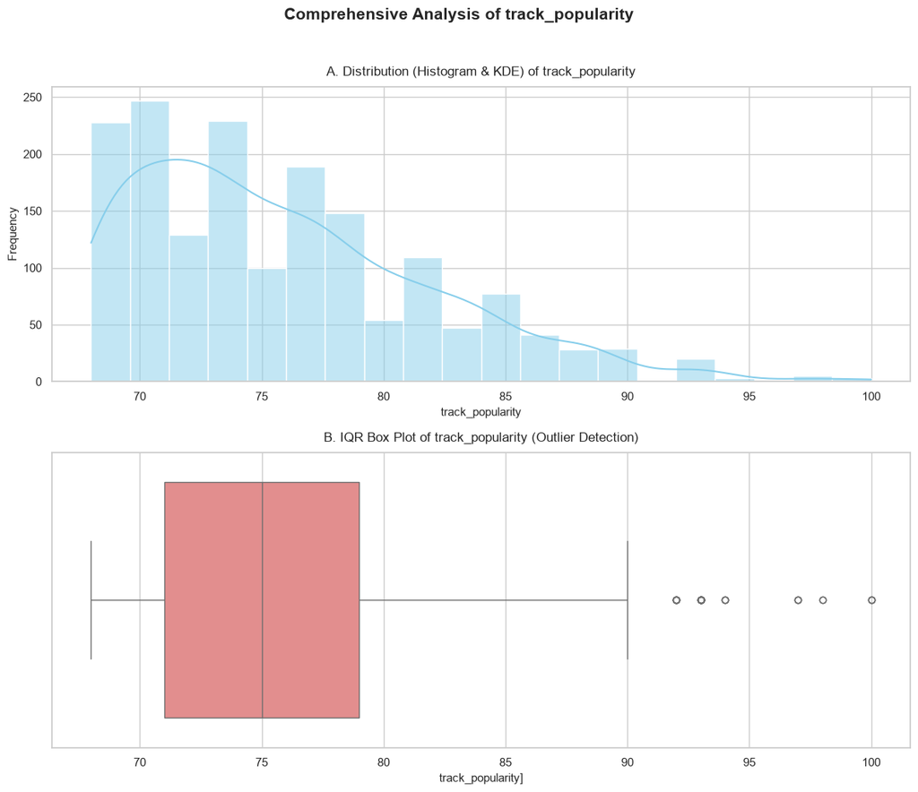

We analyzed **Track Popularity** using a dual-plot approach—a histogram stacked atop a box plot—because they complement each other perfectly to reveal both the distribution shape and the underlying statistics.

##### 3.1.2 categorical column analysis

- Pick one categorical column from the dataset.
- Create a bar chart showing how often each category appears.
- Write one observation about which category is most common and which is least common.

```
--- Frequency of playlist_genre categories ---
playlist_genre
pop           357
rock          235
hip-hop       227
latin         184
electronic    148
gaming        100
ambient        61
r&b            50
arabic         50
punk           50
blues          45
metal          35
folk           33
afrobeats      20
brazilian      14
j-pop          11
k-pop          11
classical      10
indian          9
korean          8
turkish         7
reggae          5
world           4
indie           4
country         3
soul            2
lofi            2
jazz            1
Name: count, dtype: int64


Maximum Frequency: pop (357)
Minimum Frequency: jazz (1)
Absolute Difference: 356
```

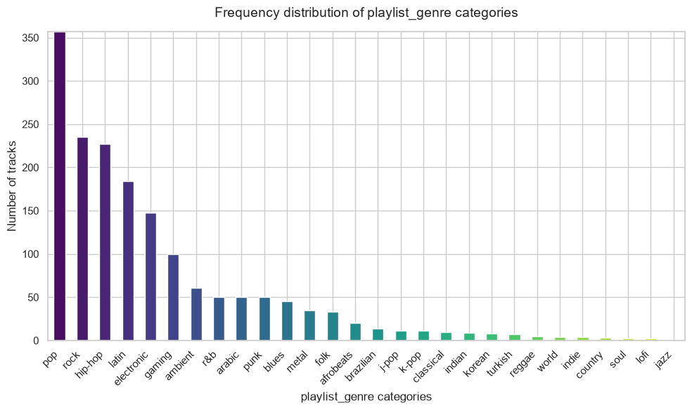

We selected the `playlist_genre` column for our categorical analysis, representing the primary genre classification of the playlists containing these highly popular tracks.

#### 3.2 Relationship Between Two Columns

##### 3.2.1 Create a correlation heatmap for all numerical columns using Seaborn.

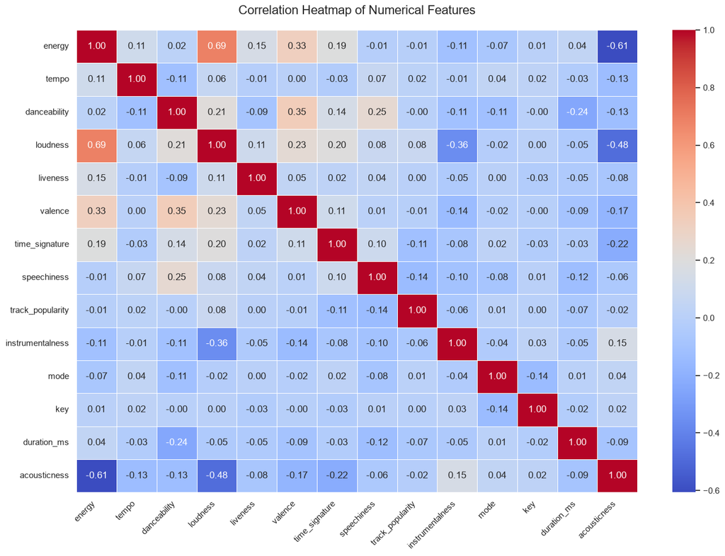

##### 3.2.2 Find the two columns that are most strongly related, ignoring self-correlation.

```
The two columns that are most strongly related are: 'energy' and 'loudness'
The correlation value is: 0.69
```

##### 3.2.4 Choose any two columns and show their relationship using:

- A scatter plot.

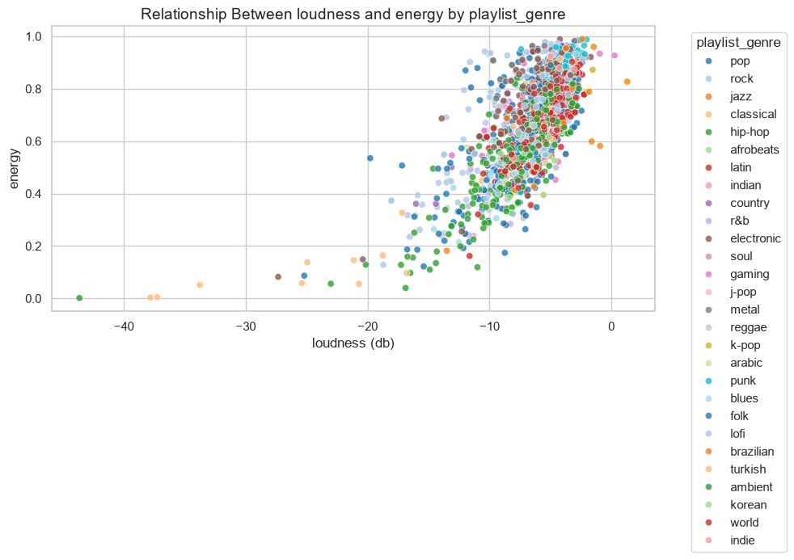

The scatter plot reveals a strong positive linear relationship between loudness and energy. As loudness increases (moving from -40 dB toward 0 dB), energy levels show a consistent, proportional rise. Notably, genres such as `Punk` and `Electronic` exhibit a high degree of density in the upper-right quadrant. This confirms that these genres, within this dataset, maintain consistently high-intensity profiles, with minimal variation in their energy and loudness levels compared to the rest of the sample(between -10 dB and 0 dB, with energy scores above 0.75).The density of points suggests that for popular tracks, maintaining a high volume is standard practice to achieve high energy ratings.

- A grouped box plot.

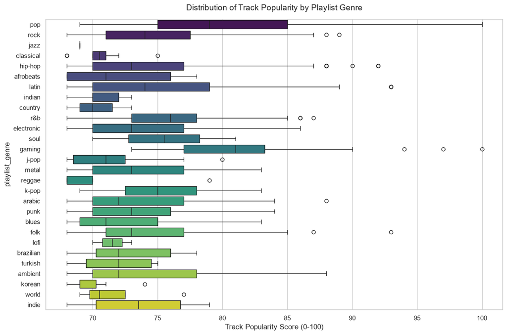

**Observation:**

```
--- Crosstab: data count by playlist_genre and  mode ---
```

| mode playlist_genre | 0 | 1 | Total |
| --- | --- | --- | --- |
| afrobeats | 8 | 12 | 20 |
| ambient | 18 | 43 | 61 |
| arabic | 30 | 20 | 50 |
| blues | 19 | 26 | 45 |
| brazilian | 6 | 8 | 14 |
| classical | 7 | 3 | 10 |
| country | 0 | 3 | 3 |
| electronic | 88 | 60 | 148 |
| folk | 5 | 28 | 33 |
| gaming | 42 | 58 | 100 |
| hip-hop | 110 | 117 | 227 |
| indian | 5 | 4 | 9 |
| indie | 3 | 1 | 4 |
| j-pop | 3 | 8 | 11 |
| jazz | 0 | 1 | 1 |
| k-pop | 5 | 6 | 11 |
| korean | 2 | 6 | 8 |
| latin | 101 | 83 | 184 |
| lofi | 1 | 1 | 2 |
| metal | 21 | 14 | 35 |
| pop | 125 | 232 | 357 |
| punk | 14 | 36 | 50 |
| r&b | 20 | 30 | 50 |
| reggae | 3 | 2 | 5 |
| rock | 67 | 168 | 235 |
| soul | 1 | 1 | 2 |
| turkish | 6 | 1 | 7 |
| world | 1 | 3 | 4 |
| Total | 711 | 975 | 1686 |

**Dominant Modes**: The dataset is heavily skewed toward Mode 1 (Major), which accounts for 975 out of the total 1,686 tracks (approx. 58%). This suggests that "highly popular" playlists on Spotify show a clear preference for the more conventionally bright and resolved sound of the Major key.

**Genre-Specific Mode Profiles**: There is a stark contrast in musical temperament across genres:

**Statistical Imbalance**: Certain genres, such as Jazz or Lofi, have extremely low sample sizes (1 and 2 tracks, respectively), which makes any analysis of their "preferred mode" statistically insignificant.

#### 3.3 Looking at Multiple Columns Together

##### 3.3.1 Create a pair plot using at least three columns.

```
--- Generating Multi-Column Pair Plot ---
```

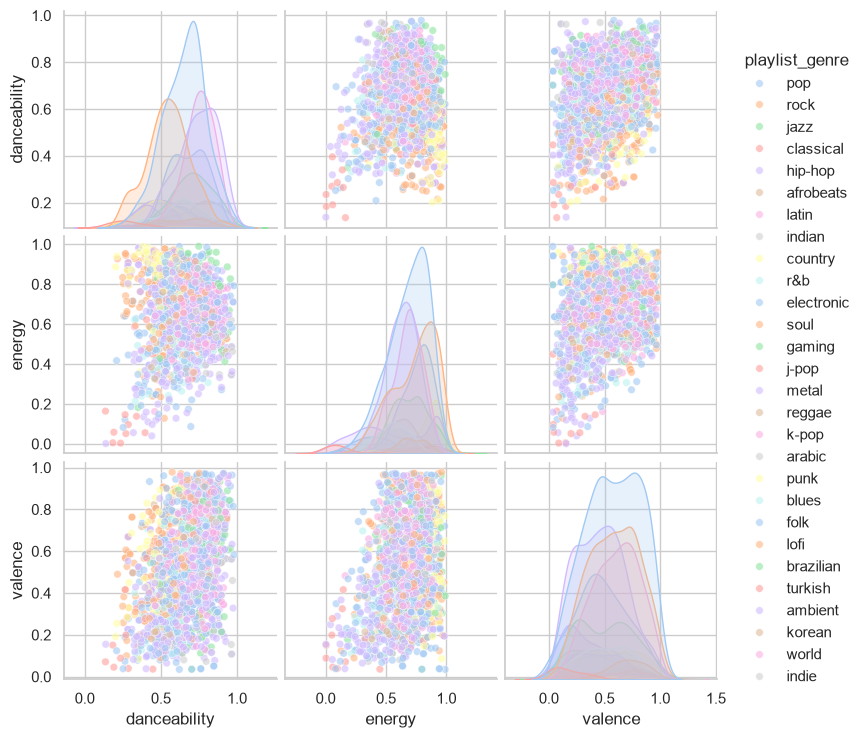

##### 3.3.3 Describe one interesting pattern or grouping that only becomes visible when looking at all selected columns together.

- From this observation, "Genre" in this dataset is likely an external label (based on branding, artist, or marketing) rather than an intrinsic audio quality. Popular music has become so standardized that a "Pop" track and an "Electronic" track are mathematically nearly identical in terms of energy and danceability.

##### 3.3.4 Explain why this insight is useful for understanding the dataset.

This multi-dimensional insight is highly useful for several reasons:

- **Model Performance Expectations**: This insight explains why a predictive model (like a Random Forest or Support Vector Machine) might struggle to classify genres with high accuracy. Because the audio features (energy, danceability, valence) are essentially homogenous across genres, the model will likely face significant misclassification issues, as the features lack the necessary "discriminatory power" to pull genres apart.
- **Defining "Popularity" vs. "Genre"**: It confirms that in this dataset, the common denominator is "High Popularity." The music industry appears to filter for a specific "popular audio profile" before a track ever reaches these playlists. The insight helps us realize that we are analyzing the characteristics of success rather than the characteristics of genres.
- **Feature Engineering Needs**: This discovery shifts the focus for further analysis. Since these primary audio features are not unique to specific genres, it suggests that to truly differentiate genres, one must look toward other columns—such as tempo, key, or perhaps the lyrical content—rather than relying on high-level energy/valence metrics.

#### 3.4 Summary of Findings

##### 3.4.4 What these results tell you about the dataset overall.

- Overall, this dataset represents a curated, elite snapshot of mainstream Spotify culture rather than a diverse, organic musical library.
- Popularity on streaming platforms is heavily formulaic—relying on loud master volumes, elevated acoustic energy, high danceability, and bright Major keys. The heavy dataset imbalance toward Pop and Rap tracks mirrors the commercial streaming dominance of those genres, making the dataset highly reflective of modern consumption trends but structurally challenging for balanced genre analysis.

### 4. Possible Machine Learning Questions

##### 4.1 Can the target variable be predicted using the most strongly correlated features?

- **Hypothetical Target Variable:** `loudness` (Continuous, Decibels)
- **Most Strongly Correlated Predictor Feature:** `energy` (Numerical, correlation value: $0.69$)
- **Justification:** The dataset is highly suitable for regression tasks. Since `energy` and `loudness` exhibit a robust, positive relationship ($r = 0.69$), we can easily train a Simple Linear Regression or Support Vector Regression (SVR) model to predict a track's master loudness using its acoustic energy. An SVR model would successfully capture the non-linear compression curve near the maximum volume limits (around -2 dB) where audio signals begin to squeeze.

### 5. Final Verdict

- The dataset is **prepared and ready** for machine learning, but several crucial pipeline transformations are required before model training.
- **Recommendations:**
  1. **Feature Scaling:** Because the features operate on wildly different scales—such as track duration (`duration_ms` in the hundreds of thousands) and `tempo` (BPM up to 200+) versus normalized audio features (`energy`, `danceability` scaled strictly between 0.0 and 1.0)—applying **StandardScaler** or **MinMaxScaler** is mandatory before training distance-sensitive models (like KNN, SVM, or K-Means).
  2. **Addressing Class Imbalance:** Due to the massive disparity in the `playlist_genre` categories, any classification task must incorporate class-balancing strategies (such as dropping extremely low-sample genres like Jazz, merging minority categories, or adjusting loss penalties) to prevent major prediction bias.